# Time Series Analysis

#### Homework5 201811526 이은주

### 4. INGA_AmsterdamDiff

INGA.AmsterdamDiff 데이터는 2010년 1월1일부터 257일간, 주가의 일별 변화에 대한 데이터입니다.  
예측을 위한 ARIMA 모델 선택을 위해 INGA.AmsterdamDiff 데이터의 여러 특징을 알아보고 가장 좋은 모델을 최종 선택하겠습니다.

#### [STEP 1] 시계열 데이터 처리

```r
inga = read.table("INGA_AmsterdamDiff.txt")
inga_ts = ts(inga, start=1, frequency=1)
head(inga_ts)
```

```
## Time Series:
## Start = 1
## End = 6
## Frequency = 1
##          V1
## [1,] -0.141
## [2,] -0.012
## [3,] -0.177
## [4,] -0.170
## [5,]  0.193
## [6,]  0.129
```

2010년 1월 1일부터 하루 주기로 측정한 주가의 변화임을 고려하여 시계열 데이터로 변환합니다.

#### [STEP 2] 시계열 그래프

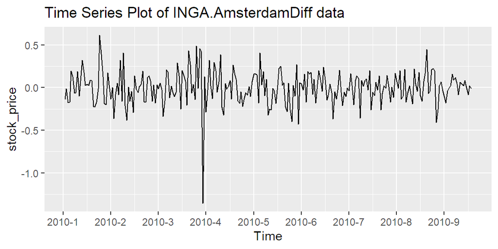

```r
date=seq(0,nrow(inga_ts),by=30)
autoplot(inga_ts) + ylab("stock_price") +
  ggtitle("Time Series Plot of INGA.AmsterdamDiff data") +
  scale_x_continuous(breaks=date, labels=paste0("2010-",date/30+1 ))
```

2010년 4월로 넘어가며 급격히 주식이 한번 하락하였으나  
대부분 변화율이 0%에서 왔다 갔다하며 어떠한 추세,계절성과 같은 특징이 전혀 보이지 않습니다.

#### [STEP 3] ACF, PACF

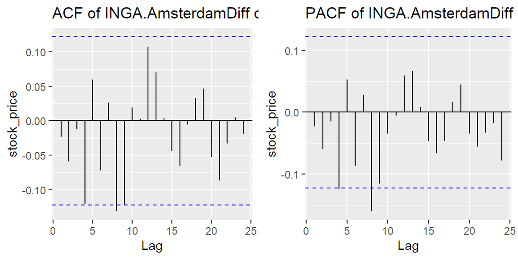

```r
p1 = ggAcf(inga_ts) + ylab("stock_price") + ggtitle("ACF of INGA.AmsterdamDiff data")
p2 = ggPacf(inga_ts) + ylab("stock_price") + ggtitle("PACF of INGA.AmsterdamDiff data")
grid.arrange(p1, p2, ncol=2)
```

ACF, PACF 모두 유의수준에서 거의 벗어나지 않습니다.  
이는 자기상관성이 없는 잔차와 같은 White noise, $Y_t$ = $a_t$, $a_t$:WN 에 해당하는 것으로 보입니다.

AutoarimaModel은 어떤 모델을 추정하는 지에 대해 확인해봅니다.

```r
train_inga = inga_ts[1:210]
test_inga = inga_ts[201:257]
AutoarimaModel = auto.arima(train_inga); print(AutoarimaModel)
```

```
## Series: train_inga
## ARIMA(0,0,0) with zero mean
##
## sigma^2 estimated as 0.04218:  log likelihood=34.43
## AIC=-66.85   AICc=-66.83   BIC=-63.51
```

마찬가지로 ARIMA(0,0,0) 즉 white noise로 추정하였습니다.

#### [STEP4] Best model

white noise의 경우 정상성 시계열의 대표적인 예로 각 시점의 관측값이 잔차와 같은 역할입니다.  
즉, t시점에서의 관측값이 t-1시점에서의 관측값에 전혀 영향을 받지 않습니다. 이에 따라 INGA.AmsterdamDiff data에 대한 모델링은 의미가 없습니다.